# LinearRegression

Steve

2025-08-27

## An example

The following data represents sales (in units) as a function of advertising budget (in thousands of dollars) for TV, radio, and newspaper.

```r
?read.csv
Advertising <- read.csv('Advertising.csv', row.names=1)
summary(Advertising)
```

```
##        TV             radio          newspaper          sales
##  Min.   :  0.70   Min.   : 0.000   Min.   :  0.30   Min.   : 1.60
##  1st Qu.: 74.38   1st Qu.: 9.975   1st Qu.: 12.75   1st Qu.:10.38
##  Median :149.75   Median :22.900   Median : 25.75   Median :12.90
##  Mean   :147.04   Mean   :23.264   Mean   : 30.55   Mean   :14.02
##  3rd Qu.:218.82   3rd Qu.:36.525   3rd Qu.: 45.10   3rd Qu.:17.40
##  Max.   :296.40   Max.   :49.600   Max.   :114.00   Max.   :27.00
```

Do we think there’s a linear relationship between TV advertising and sales? I.e are there coefficients $\beta_0$ and $\beta_1$ such that $sales = \beta_0 + \beta_1*TV + \varepsilon$?

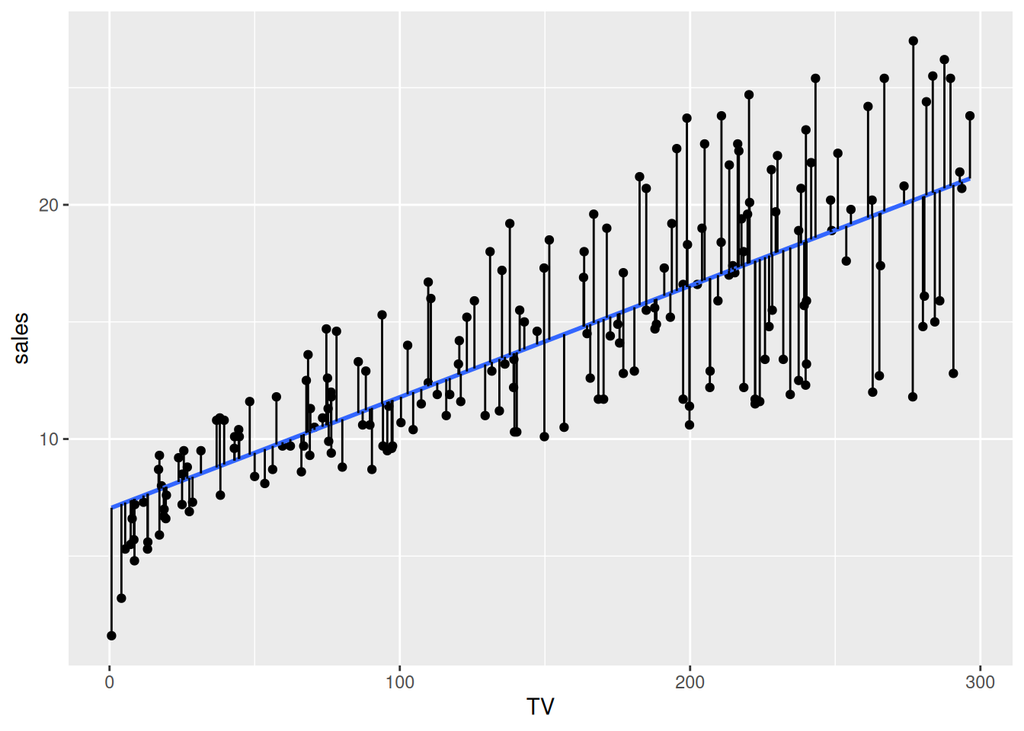

```r
Advertising %>%
  lm(sales ~ TV, data=.) %>%
  augment() %>%
  ggplot(mapping=aes(x=TV, y=sales)) +
  geom_point() +
  geom_smooth(method="lm", se=FALSE) +
  geom_segment(aes(xend=TV, yend=.fitted))
```

So here
$$sales = \beta_0 + \beta_1*TV +
\varepsilon.$$
If $e_j = sales_j - \beta_0 - \beta_1*TV_j$, we call $e_j$ the *residual* of the linear model. We define the *residual sum of squares* by
$$RSS = \sum_{j=1}^n e_j^2.$$

In this one-variable case, we can write down a formula for $\beta_0$, $\beta_1$ (see page 62 of ISL), but such formulae become intractable when there is more than one feature. There is, however, a “simple” formula for computing linear regression coefficients if you’re willing to deal with matrices.

```r
Advertising %>%
  lm(sales ~ TV, data=.) %>%
  summary()
```

```
##
## Call:
## lm(formula = sales ~ TV, data = .)
##
## Residuals:
##     Min      1Q  Median      3Q     Max
## -8.3860 -1.9545 -0.1913  2.0671  7.2124
##
## Coefficients:
##             Estimate Std. Error t value Pr(>|t|)
## (Intercept) 7.032594   0.457843   15.36   <2e-16 ***
## TV          0.047537   0.002691   17.67   <2e-16 ***
## ---
## Signif. codes:  0 '***' 0.001 '**' 0.01 '*' 0.05 '.' 0.1 ' ' 1
##
## Residual standard error: 3.259 on 198 degrees of freedom
## Multiple R-squared:  0.6119, Adjusted R-squared:  0.6099
## F-statistic: 312.1 on 1 and 198 DF,  p-value: < 2.2e-16
```

What does all this mean? Well, easiest to explain is that $\beta_0 = 7.033$ and $\beta_1 = 0.048$ are the least-squares estimate of the coefficients. We can imagine that these are *estimates* of the *true* coefficients that relate TV advertising to sales. In the same way a sample mean $\hat{\mu}$ estimates a true mean $\mu$, we assume that $\beta_0$ and $\beta_1$ estimate the true coefficients. Analogously to the well-known formula
$$Var(\hat{\mu}) = SE(\hat{\mu})^2 =
\frac{\sigma^2}{n},$$
there formulae for the standard errors (page 66) for $\beta_0$ and $\beta_1$.

The estimate for $\sigma$ in this case is given by the *residual standard error*:
$$RSE = \sqrt{\frac{RSS}{n-2}}$$
.

We can use these standard errors to do hypothesis testing: Suppose we have a null hypothesis of
$$H_0: \mbox{
$sales$ and $TV$ have no relationship}$$
or
$$H_0: \beta_1 = 0$$
or the alternate hypothesis
$$H_a: \beta_1 \neq 0$$
. We can look at the t-statistic
$$t =
\frac{\beta_1}{SE(\beta_1)}$$
which in the case of our advertising data, chalks up to be about 17.67.

The last column is a $p$-value. The $t$-statistic is known to have a $t$-distribution with n-2 degrees of freedom. For $n$ > 30, this is well-approximated by a normal distribution, so $p$-values of around 0.01 or 0.05 would correspond to $t$-statistics of 2.75 or 2 respectively. Therefore, we can reject the null hypothesis in this case and say that $\beta_1 \neq 0$.

### How good is this fit?

The *total sum of squares*
$$TSS =
\sum_{j=1}^n (y_j-\bar{y})^2$$
measures the total variance in the response. The $R^2$ statistic is defined by:
$$R^2 = 1 -
\frac{RSS}{TSS}$$
. Intuitively, if RSS is small compared to TSS, most of the variance is explained by the linear model.

## Multiple Features

We can likewise look at the models for $newspaper$ and $radio$:

```r
Advertising %>%
  lm(sales ~ newspaper, data=.) %>%
  summary()
```

```
##
## Call:
## lm(formula = sales ~ newspaper, data = .)
##
## Residuals:
##      Min       1Q   Median       3Q      Max
## -11.2272  -3.3873  -0.8392   3.5059  12.7751
##
## Coefficients:
##             Estimate Std. Error t value Pr(>|t|)
## (Intercept) 12.35141    0.62142   19.88  < 2e-16 ***
## newspaper    0.05469    0.01658    3.30  0.00115 **
## ---
## Signif. codes:  0 '***' 0.001 '**' 0.01 '*' 0.05 '.' 0.1 ' ' 1
##
## Residual standard error: 5.092 on 198 degrees of freedom
## Multiple R-squared:  0.05212,    Adjusted R-squared:  0.04733
## F-statistic: 10.89 on 1 and 198 DF,  p-value: 0.001148
```

and

```r
Advertising %>%
  lm(sales ~ radio, data=.) -> model1
summary(model1)
```

```
##
## Call:
## lm(formula = sales ~ radio, data = .)
##
## Residuals:
##      Min       1Q   Median       3Q      Max
## -15.7305  -2.1324   0.7707   2.7775   8.1810
##
## Coefficients:
##             Estimate Std. Error t value Pr(>|t|)
## (Intercept)  9.31164    0.56290  16.542   <2e-16 ***
## radio        0.20250    0.02041   9.921   <2e-16 ***
## ---
## Signif. codes:  0 '***' 0.001 '**' 0.01 '*' 0.05 '.' 0.1 ' ' 1
##
## Residual standard error: 4.275 on 198 degrees of freedom
## Multiple R-squared:  0.332,  Adjusted R-squared:  0.3287
## F-statistic: 98.42 on 1 and 198 DF,  p-value: < 2.2e-16
```

However, we might find it most effective to model sales using all three advertising modes combined:
$$sales =
\beta_0 + \beta_1 * TV + \beta_2 * newspaper + \beta_3 * radio +
\varepsilon$$

```r
Advertising %>%
  lm(sales ~ TV+newspaper +radio, data=.) -> model1
summary(model1)
```

```
##
## Call:
## lm(formula = sales ~ TV + newspaper + radio, data = .)
##
## Residuals:
##     Min      1Q  Median      3Q     Max
## -8.8277 -0.8908  0.2418  1.1893  2.8292
##
## Coefficients:
##              Estimate Std. Error t value Pr(>|t|)
## (Intercept)  2.938889   0.311908   9.422   <2e-16 ***
## TV           0.045765   0.001395  32.809   <2e-16 ***
## newspaper   -0.001037   0.005871  -0.177     0.86
## radio        0.188530   0.008611  21.893   <2e-16 ***
## ---
## Signif. codes:  0 '***' 0.001 '**' 0.01 '*' 0.05 '.' 0.1 ' ' 1
##
## Residual standard error: 1.686 on 196 degrees of freedom
## Multiple R-squared:  0.8972, Adjusted R-squared:  0.8956
## F-statistic: 570.3 on 3 and 196 DF,  p-value: < 2.2e-16
```

Notice that when $newspaper$ is the lone feature, it’s very likely that the newspaper coefficient is non-zero, but here, it’s very likely to be zero. This is due to radio and newspaper having very strong *confounding* effects. As per the classic example: If we look at ice cream sales and shark attacks on a given beach, they’re likely to have a strong linear relationship, but ice cream sales doesn’t *cause* shark attacks. There are more people at the beach when it’s hot.

Here the *correct* hypotheses are:
$$H_0: \beta_1 = \beta_2 = \ldots = \beta_p =
0$$
and
$$H_a: \beta_j \neq 0 \mbox{
for some $j$}.$$

### The F-statistic

The $F$-statistic is given by:
$$F = \frac{(TSS - RSS)/p}{RSS/(n - p - 1)}$$
.

The expectation of the denominator is $\sigma^2$. Under the null hypothesis, the expectation of the numerator is also $\sigma^2$. Hence, if $F$ is close to 1, we accept the null hypothesis and reject otherwise.

## Interaction terms

It might be that spending *only* on TV or radio does not optimize sales and that investing in both has a synergistic effect.

```r
Advertising %>%
  lm(sales ~ TV + radio + TV*radio, data=.) %>%
  summary()
```

```
##
## Call:
## lm(formula = sales ~ TV + radio + TV * radio, data = .)
##
## Residuals:
##     Min      1Q  Median      3Q     Max
## -6.3366 -0.4028  0.1831  0.5948  1.5246
##
## Coefficients:
##              Estimate Std. Error t value Pr(>|t|)
## (Intercept) 6.750e+00  2.479e-01  27.233   <2e-16 ***
## TV          1.910e-02  1.504e-03  12.699   <2e-16 ***
## radio       2.886e-02  8.905e-03   3.241   0.0014 **
## TV:radio    1.086e-03  5.242e-05  20.727   <2e-16 ***
## ---
## Signif. codes:  0 '***' 0.001 '**' 0.01 '*' 0.05 '.' 0.1 ' ' 1
##
## Residual standard error: 0.9435 on 196 degrees of freedom
## Multiple R-squared:  0.9678, Adjusted R-squared:  0.9673
## F-statistic:  1963 on 3 and 196 DF,  p-value: < 2.2e-16
```